# Analyse des hypotheses sur la répartition des plans d’eau en Bretagne et Pays de la Loire

### Selon les communes

Nous avons réitéré le traitement sur les communes de la zone d’étude, pour en comparer les résultats.

Voici la densité numérique de plans d’eau des communes en fonction de la proportion de surface en maraichage :

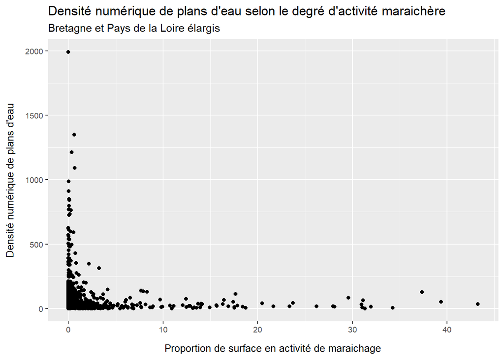

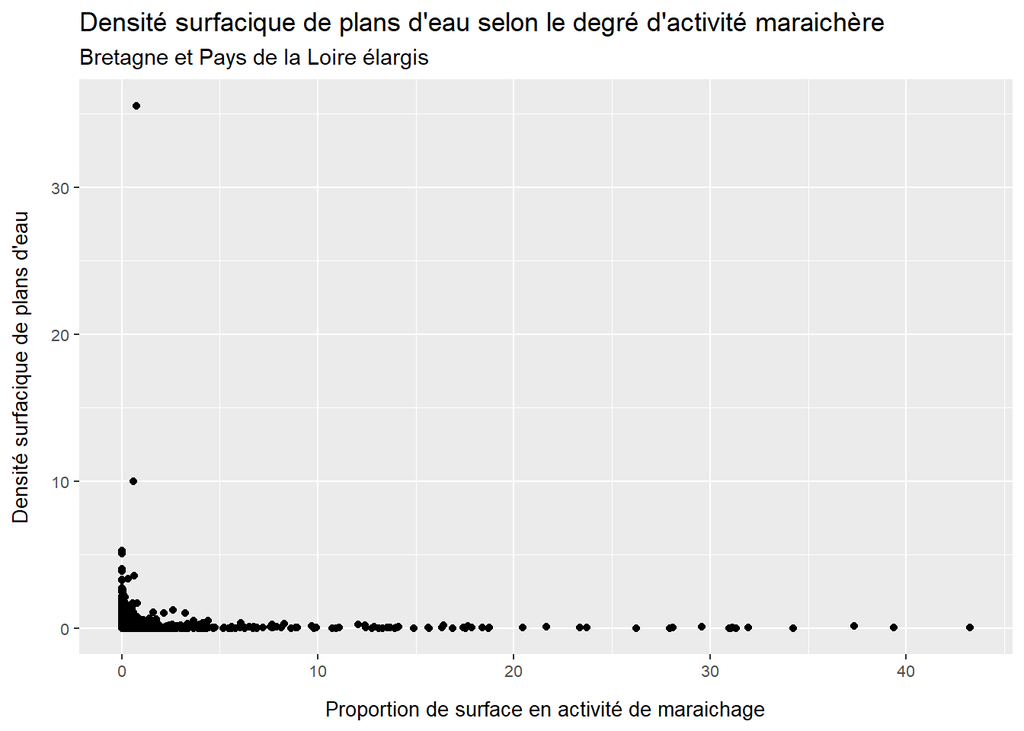

Si on exclue des plans d’eau les mares et marais, la répartition des densités numériques est la suivantes :

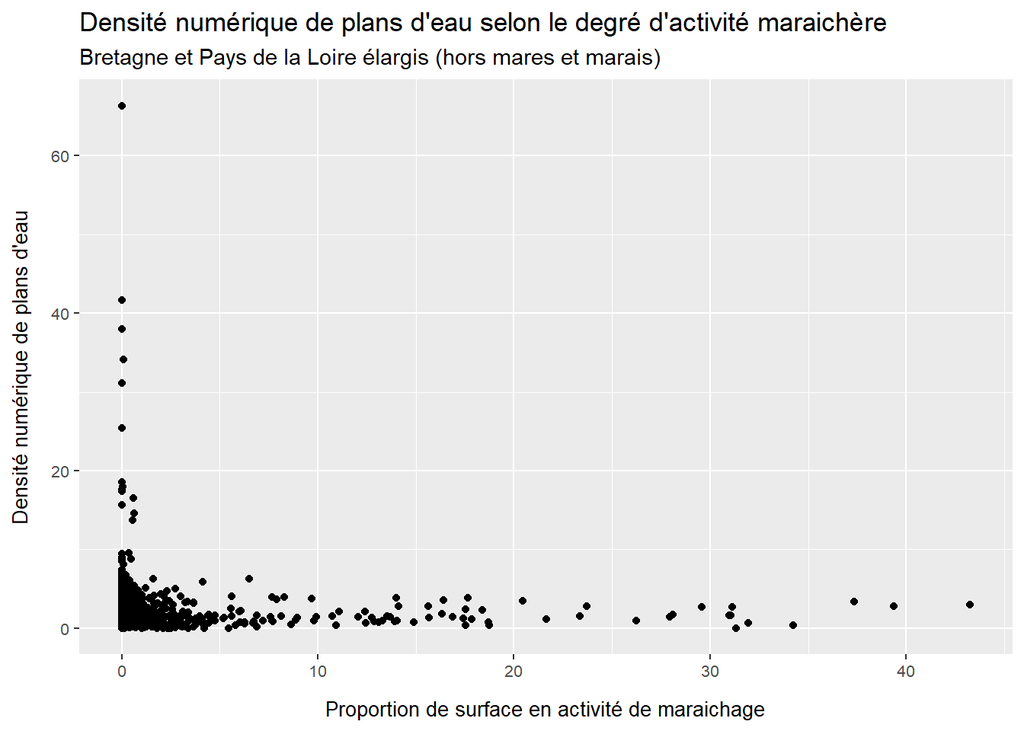

La répartition des densités surfaciques :

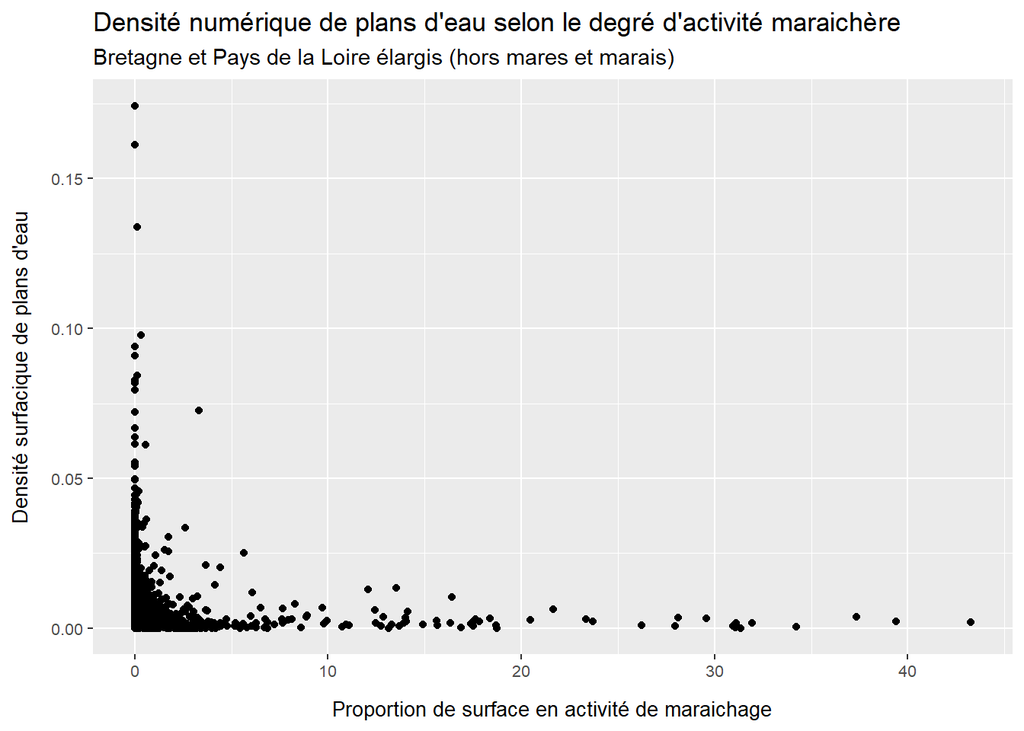

Il est également possible de regarder les densités relatives de plans d’eau selon des classes de proportion en activité maraichère :

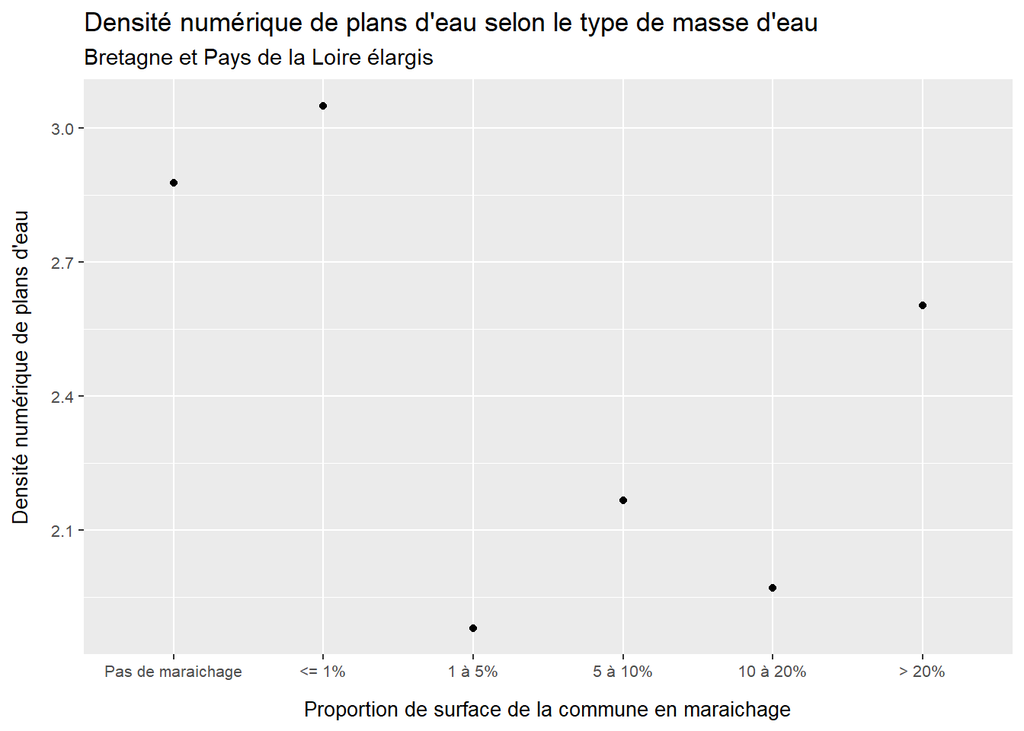

En limitant aux plans d’eau hors mares et marais :

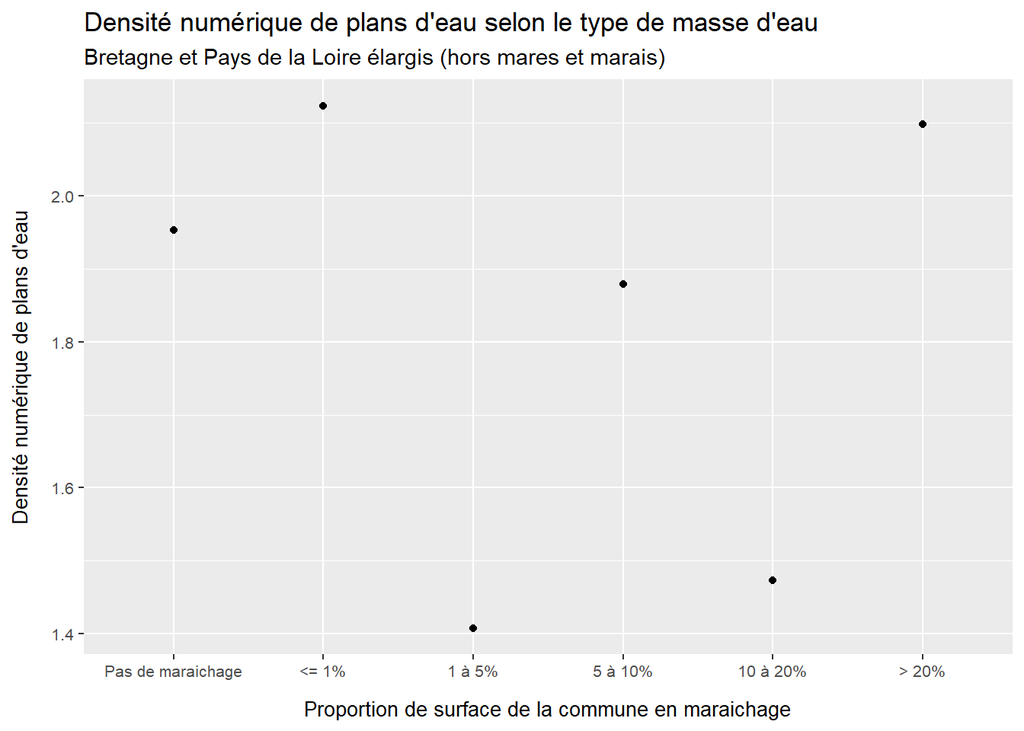

### Conclusion

Il ne semble pas y avoir de lien fort entre activité de maraichage et densité numérique de plans d’eau. C’est en effet les masses d’eau dont les proportions de surface en maraîchage sont les plus faibles (dépourvues d’activité de maraichage ou en deça de 1% de leur surface), qui rencontrent les densités les plus fortes.

A noter toutefois, et cela se vérifie avec un découpage plus fin à l’échelle de la commune, qu’à partir de 7 à 8% d’occupation du sol en activité de maraîchage, la densité numérique semble légèrement augmenter avec la proportion de culture.

Pas de tendance visible concernant la densité surfacique, elle ne semble pas liée à l’activité de maraîchage.